# P5 Submission

Sergio Comuñas

30 de agosto de 2017

I’ve chosen Red Wine Quality dataset because here in Spain there’s a lot of good wines and it’s interesting for me.

In the “WineQualityRedDescription.txt” file you can see the dataset description.

# Univariate Plots Section

We can observe the dimensions of the dataset:

```
## 1599 rows and 13 features
```

Also we can view a short summary in terms of each feature and the numbering values of it:

```
## 'data.frame':    1599 obs. of  13 variables:
##  $ X                   : int  1 2 3 4 5 6 7 8 9 10 ...
##  $ fixed.acidity       : num  7.4 7.8 7.8 11.2 7.4 7.4 7.9 7.3 7.8 7.5 ...
##  $ volatile.acidity    : num  0.7 0.88 0.76 0.28 0.7 0.66 0.6 0.65 0.58 0.5 ...
##  $ citric.acid         : num  0 0 0.04 0.56 0 0 0.06 0 0.02 0.36 ...
##  $ residual.sugar      : num  1.9 2.6 2.3 1.9 1.9 1.8 1.6 1.2 2 6.1 ...
##  $ chlorides           : num  0.076 0.098 0.092 0.075 0.076 0.075 0.069 0.065 0.073 0.071 ...
##  $ free.sulfur.dioxide : num  11 25 15 17 11 13 15 15 9 17 ...
##  $ total.sulfur.dioxide: num  34 67 54 60 34 40 59 21 18 102 ...
##  $ density             : num  0.998 0.997 0.997 0.998 0.998 ...
##  $ pH                  : num  3.51 3.2 3.26 3.16 3.51 3.51 3.3 3.39 3.36 3.35 ...
##  $ sulphates           : num  0.56 0.68 0.65 0.58 0.56 0.56 0.46 0.47 0.57 0.8 ...
##  $ alcohol             : num  9.4 9.8 9.8 9.8 9.4 9.4 9.4 10 9.5 10.5 ...
##  $ quality             : int  5 5 5 6 5 5 5 7 7 5 ...
```

```
##        X          fixed.acidity   volatile.acidity  citric.acid
##  Min.   :   1.0   Min.   : 4.60   Min.   :0.1200   Min.   :0.000
##  1st Qu.: 400.5   1st Qu.: 7.10   1st Qu.:0.3900   1st Qu.:0.090
##  Median : 800.0   Median : 7.90   Median :0.5200   Median :0.260
##  Mean   : 800.0   Mean   : 8.32   Mean   :0.5278   Mean   :0.271
##  3rd Qu.:1199.5   3rd Qu.: 9.20   3rd Qu.:0.6400   3rd Qu.:0.420
##  Max.   :1599.0   Max.   :15.90   Max.   :1.5800   Max.   :1.000
##  residual.sugar     chlorides       free.sulfur.dioxide
##  Min.   : 0.900   Min.   :0.01200   Min.   : 1.00
##  1st Qu.: 1.900   1st Qu.:0.07000   1st Qu.: 7.00
##  Median : 2.200   Median :0.07900   Median :14.00
##  Mean   : 2.539   Mean   :0.08747   Mean   :15.87
##  3rd Qu.: 2.600   3rd Qu.:0.09000   3rd Qu.:21.00
##  Max.   :15.500   Max.   :0.61100   Max.   :72.00
##  total.sulfur.dioxide    density             pH          sulphates
##  Min.   :  6.00       Min.   :0.9901   Min.   :2.740   Min.   :0.3300
##  1st Qu.: 22.00       1st Qu.:0.9956   1st Qu.:3.210   1st Qu.:0.5500
##  Median : 38.00       Median :0.9968   Median :3.310   Median :0.6200
##  Mean   : 46.47       Mean   :0.9967   Mean   :3.311   Mean   :0.6581
##  3rd Qu.: 62.00       3rd Qu.:0.9978   3rd Qu.:3.400   3rd Qu.:0.7300
##  Max.   :289.00       Max.   :1.0037   Max.   :4.010   Max.   :2.0000
##     alcohol         quality
##  Min.   : 8.40   Min.   :3.000
##  1st Qu.: 9.50   1st Qu.:5.000
##  Median :10.20   Median :6.000
##  Mean   :10.42   Mean   :5.636
##  3rd Qu.:11.10   3rd Qu.:6.000
##  Max.   :14.90   Max.   :8.000
```

The first feature I’m interested in is “Quality” that gives us the wine score between 0 and 10):

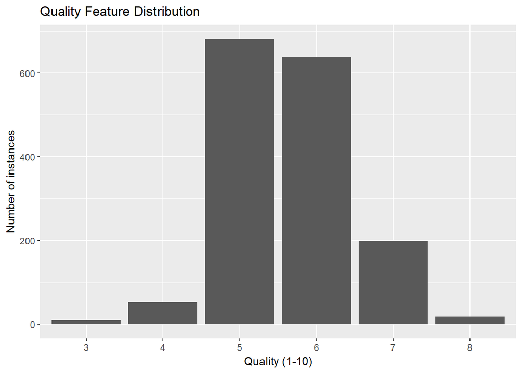

The next one gives us a vision about alcohol density:

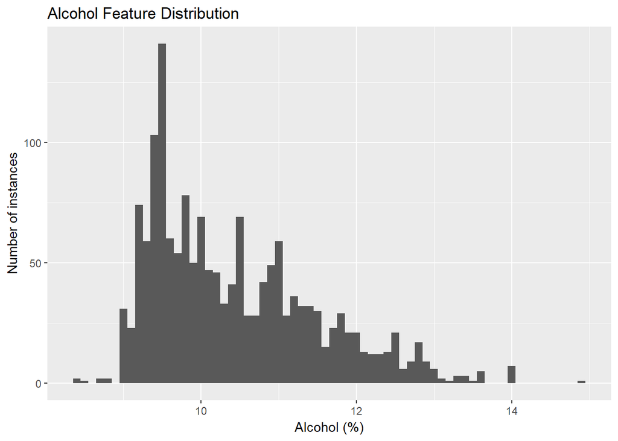

Also I want to take a look to the sulphates feature because here in my house always have discussion about the quantity of each one:

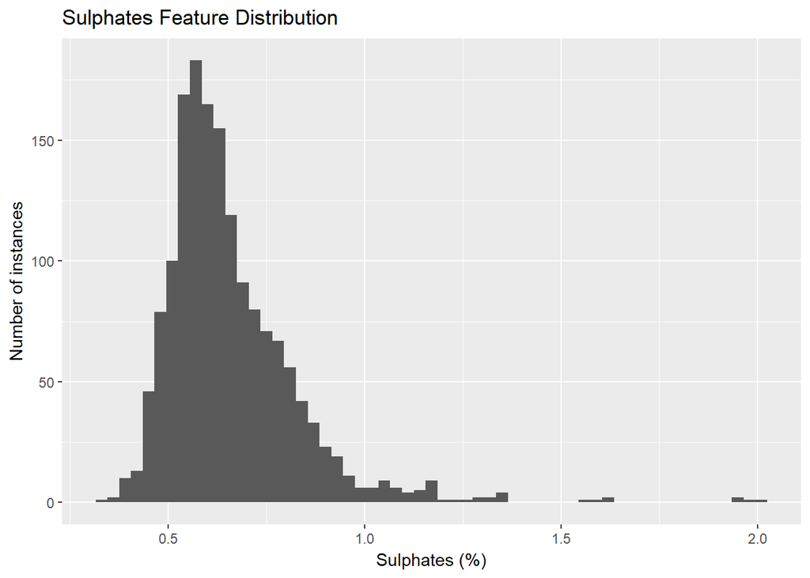

Here is the distribution for Fixed Acidity:

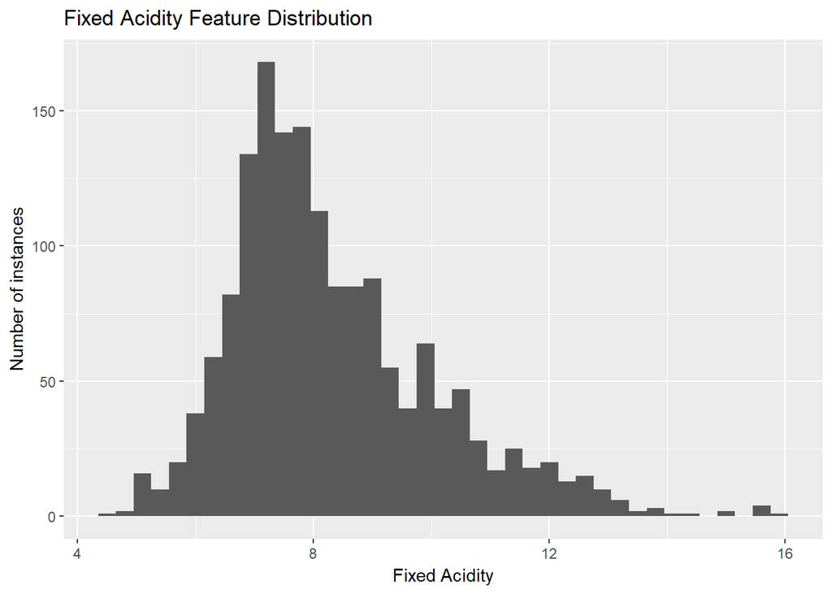

Here is the distribution for Volatile Acidity:

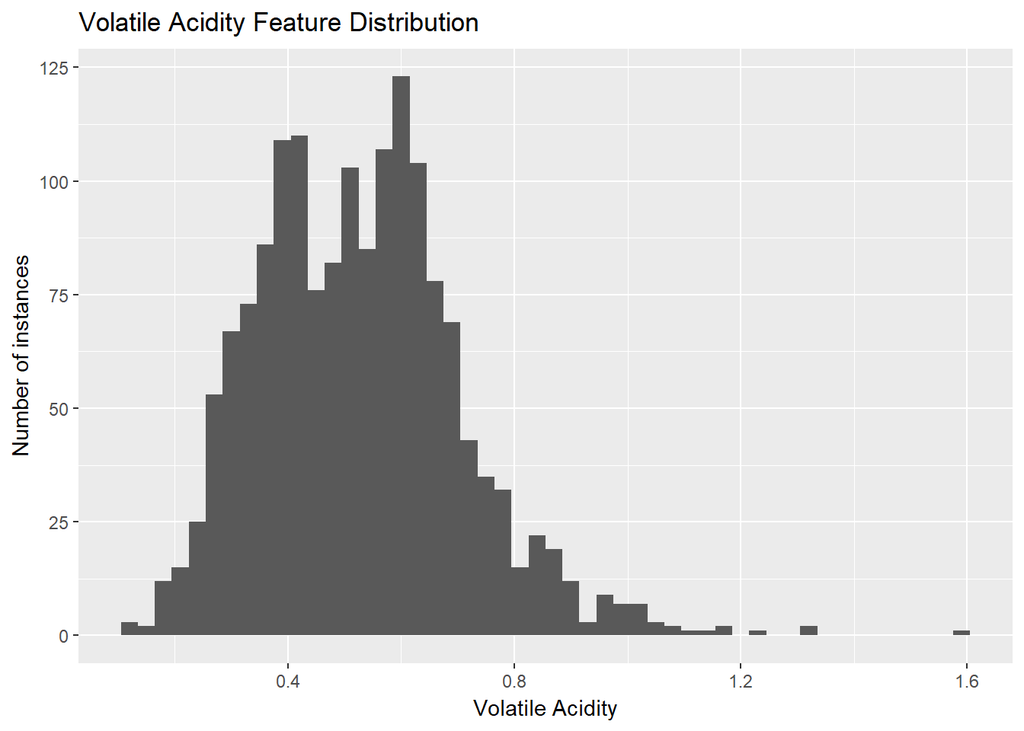

Here is the distribution for Citric Acidity:

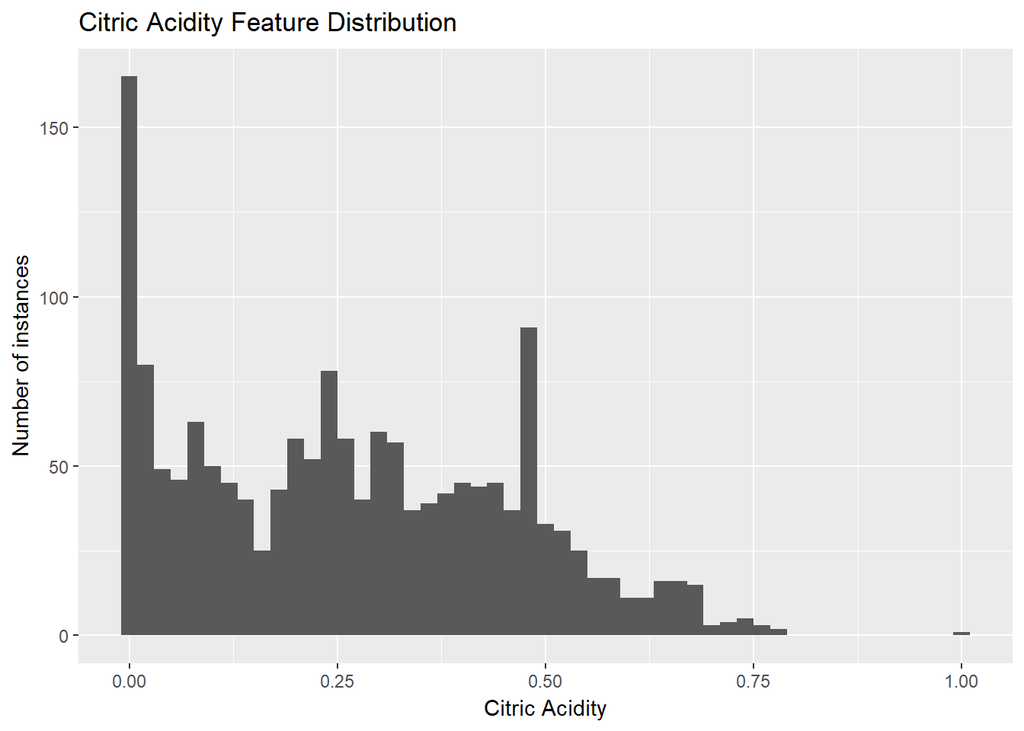

Here is the distribution for Residual Sugar:

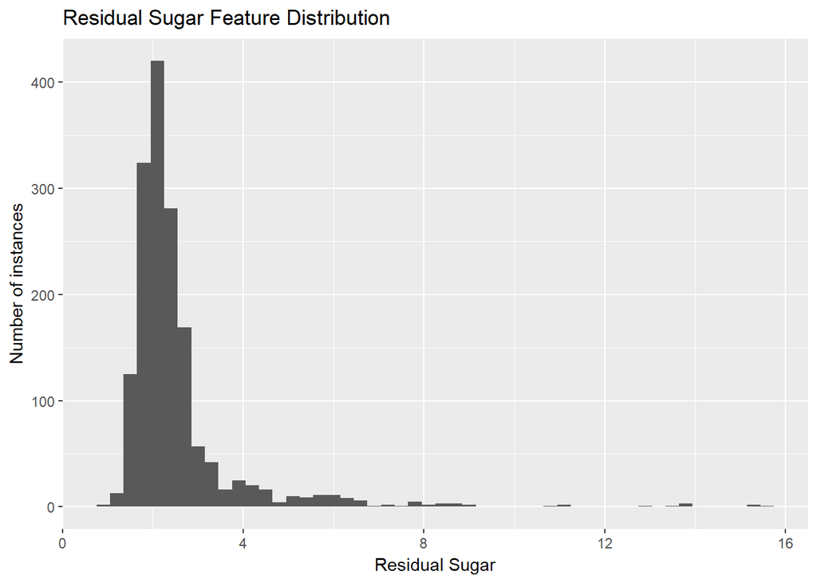

Here is the distribution for Chlorides:

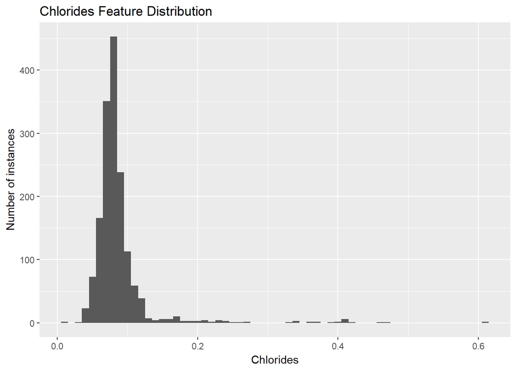

Here is the distribution for Free Sulfur Dioxide:

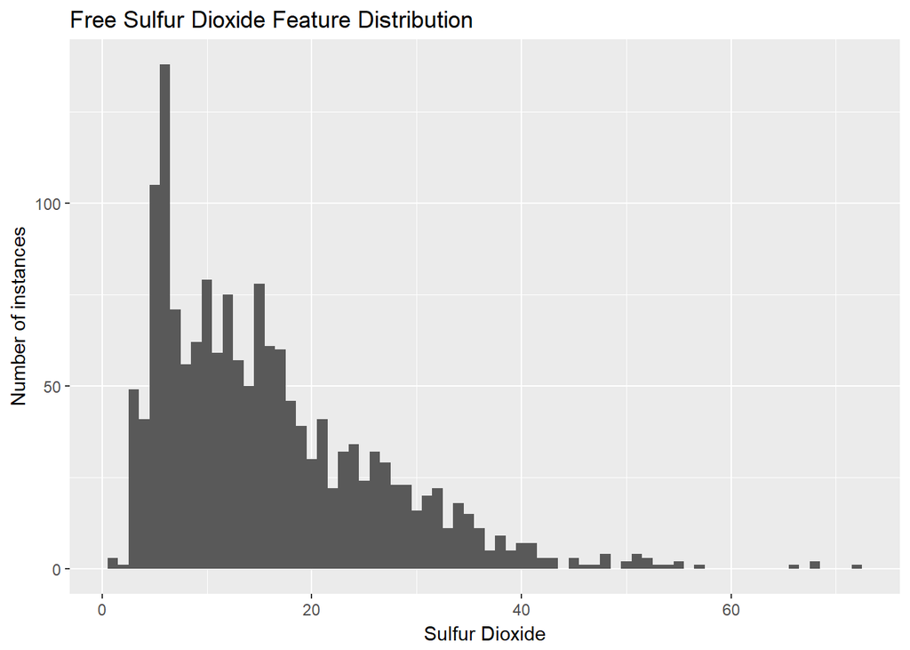

Here is the distribution for Total Sulfur Dioxide:

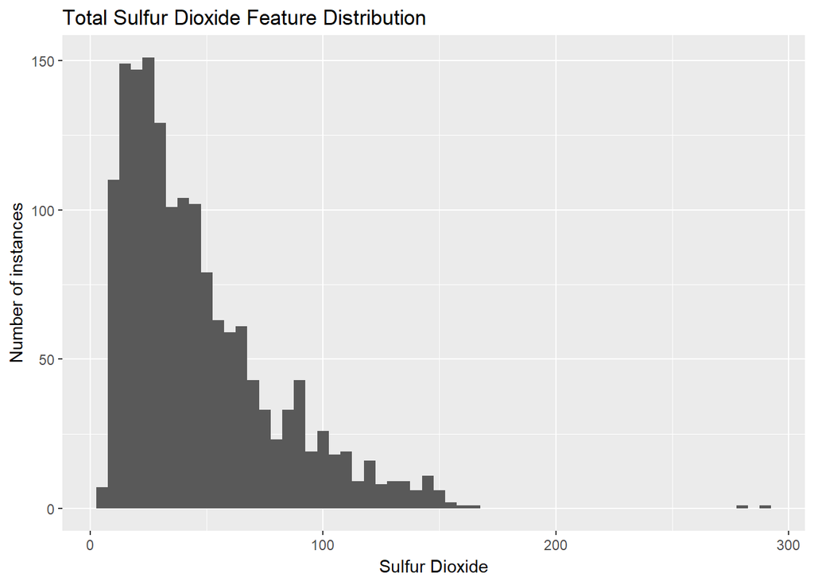

Here is the distribution for Density:

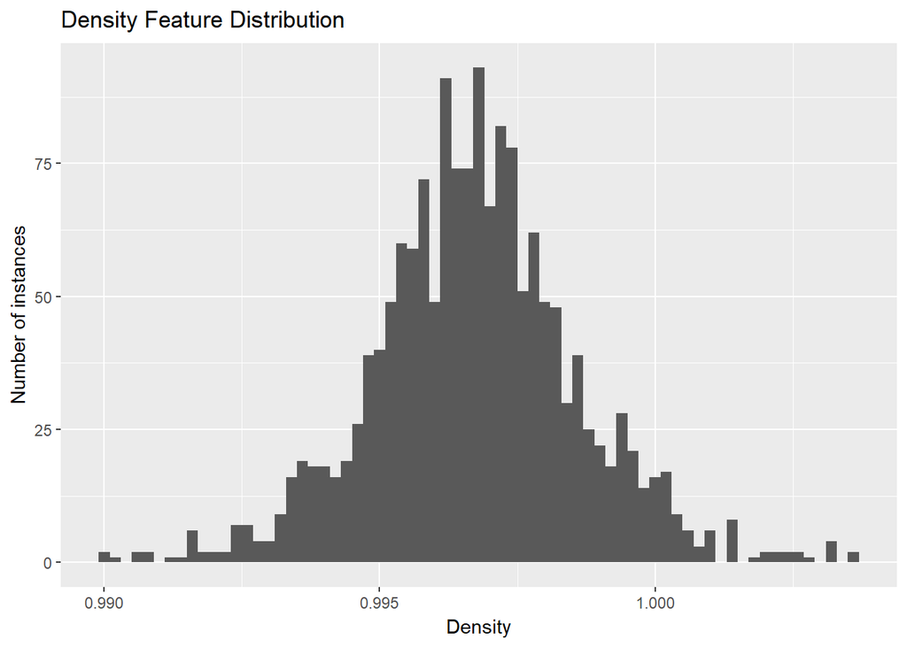

Here is the distribution for pH:

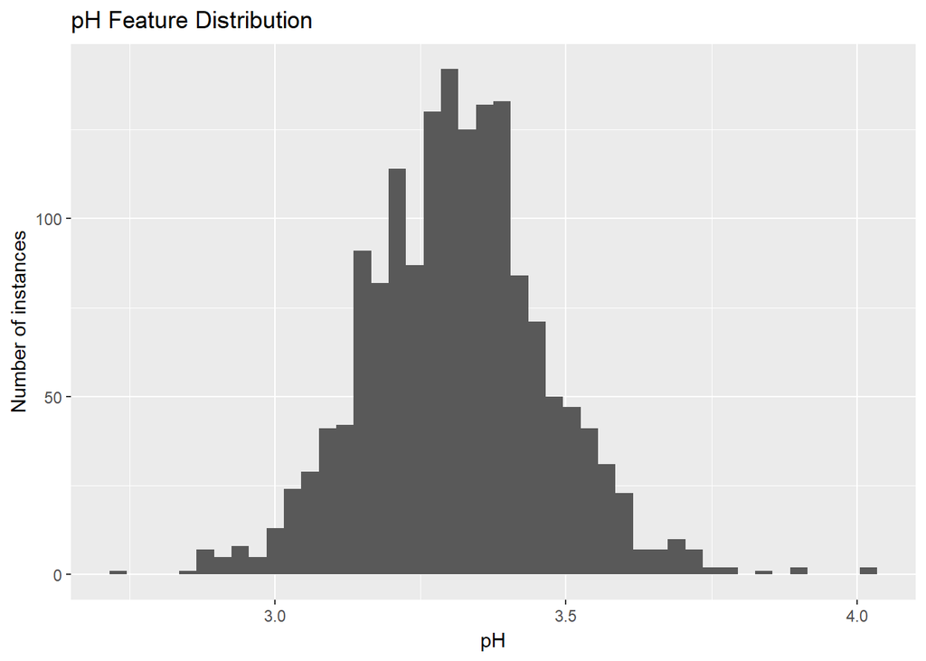

# Univariate Analysis

For me the main feature is quality. In most of the cases quality must converge in a combination of other features to give most feeling to the wine.

Other variables in this dataset are the ones reliable to reality. The ones that every people can feel driking the wine. Then: Acidity, Residual Sugar, Chlorides, Sulfur Dioxide, Density, pH, Sulphates and Alcohol.

Again there’s a median detail about each feature:

```
##        X             quality         acidity       residual.sugar
##  Min.   :   1.0   Min.   :3.000   Min.   : 5.270   Min.   : 0.900
##  1st Qu.: 400.5   1st Qu.:5.000   1st Qu.: 7.827   1st Qu.: 1.900
##  Median : 800.0   Median :6.000   Median : 8.720   Median : 2.200
##  Mean   : 800.0   Mean   :5.636   Mean   : 9.118   Mean   : 2.539
##  3rd Qu.:1199.5   3rd Qu.:6.000   3rd Qu.:10.070   3rd Qu.: 2.600
##  Max.   :1599.0   Max.   :8.000   Max.   :17.045   Max.   :15.500
##    chlorides       total.sulfur.dioxide    density             pH
##  Min.   :0.01200   Min.   :  6.00       Min.   :0.9901   Min.   :2.740
##  1st Qu.:0.07000   1st Qu.: 22.00       1st Qu.:0.9956   1st Qu.:3.210
##  Median :0.07900   Median : 38.00       Median :0.9968   Median :3.310
##  Mean   :0.08747   Mean   : 46.47       Mean   :0.9967   Mean   :3.311
##  3rd Qu.:0.09000   3rd Qu.: 62.00       3rd Qu.:0.9978   3rd Qu.:3.400
##  Max.   :0.61100   Max.   :289.00       Max.   :1.0037   Max.   :4.010
##    sulphates         alcohol
##  Min.   :0.3300   Min.   : 8.40
##  1st Qu.:0.5500   1st Qu.: 9.50
##  Median :0.6200   Median :10.20
##  Mean   :0.6581   Mean   :10.42
##  3rd Qu.:0.7300   3rd Qu.:11.10
##  Max.   :2.0000   Max.   :14.90
```

The last thing you can observe is that there are clear outliers for: Sulphates, Residual Sugar, Chloride and Sulfur Dioxide.

# Bivariate Plots Section

First of all I want to see correlation for all the features:

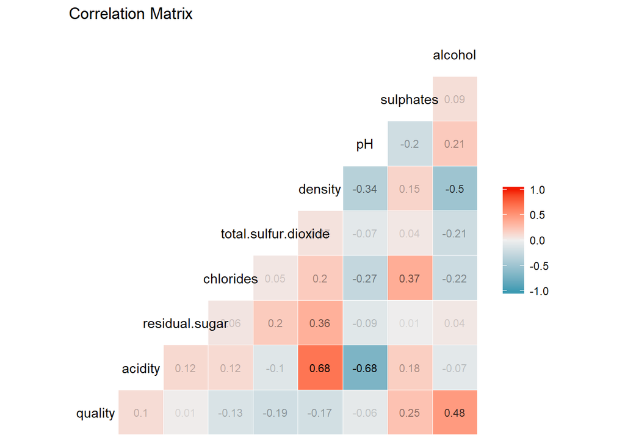

As you can see strongest correlation with quality is for alcohol feature. Here we can see relation between quality and alcohol:

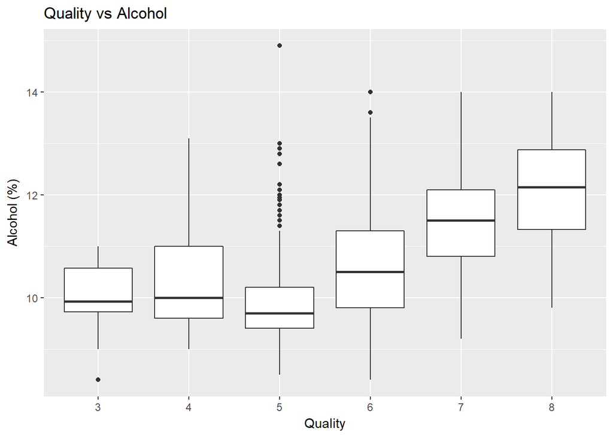

Another relative quality correlation seen is with sulphates:

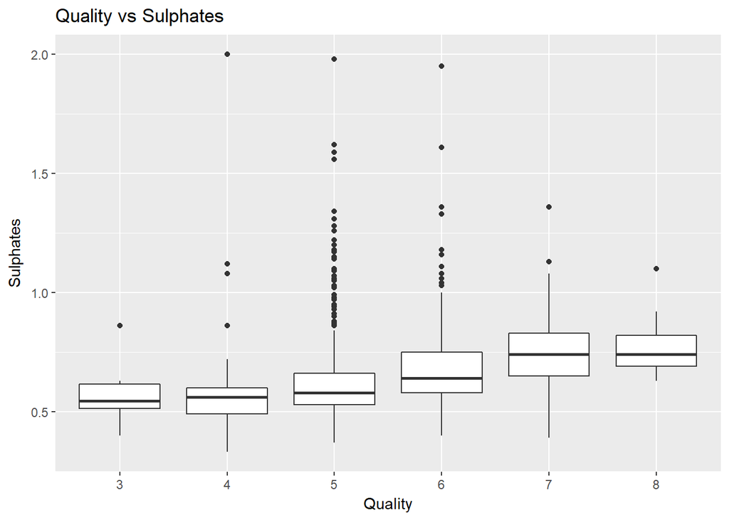

The strongest relation you can observe is acidity vs density and acidity vs pH. Let’s see:

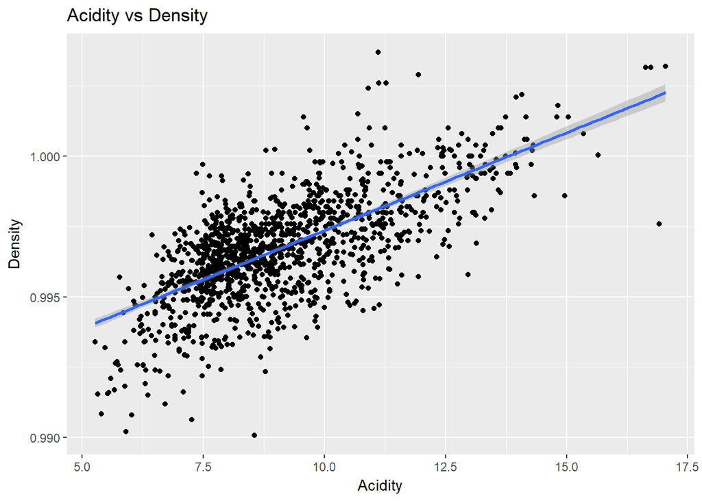

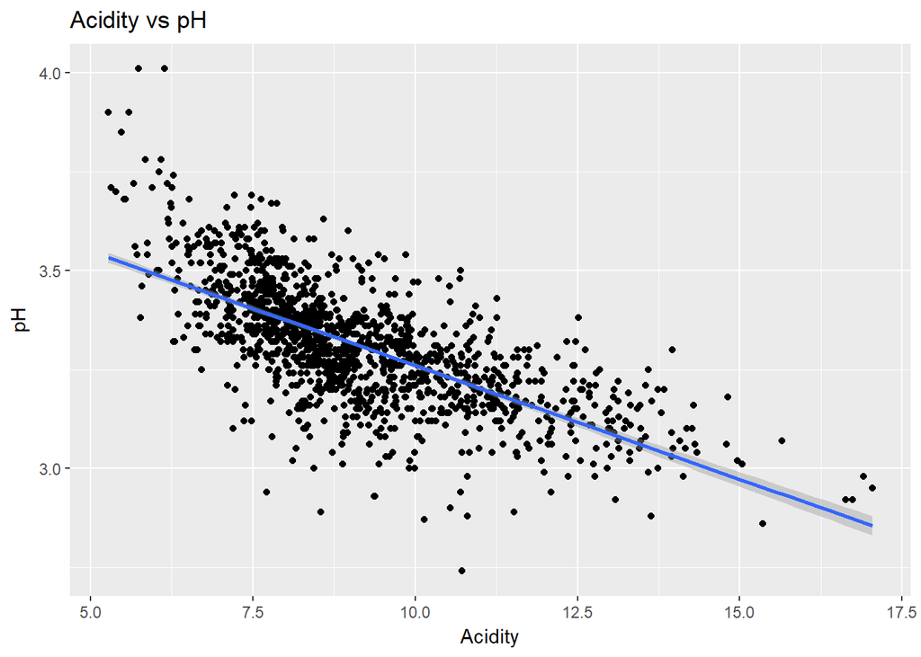

The last relation I want to observe is Sugar vs alcohol. I’ve heard from child that sugar is the ones come to alcohol after fermentation. Then, mainly the less sugar remaining would become more alcohol. Let’s see:

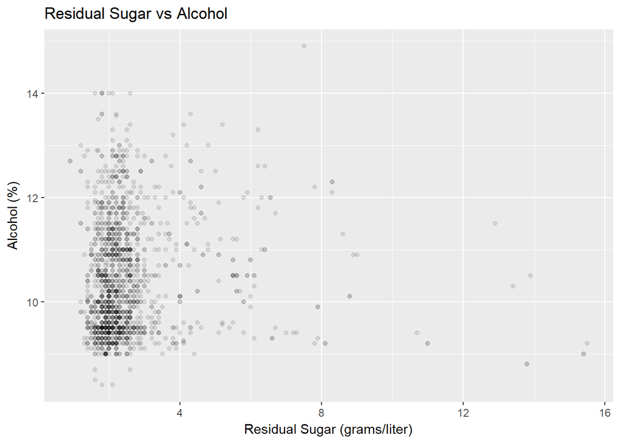

# Bivariate Analysis

We can do a first approach of the mean of each feature for every punctuation in quality:

| Quality | Acidity | Residual Sugar | Chlorides | Sulfur Dioxide | Density | pH | Sulphates | Alcohol |
| --- | --- | --- | --- | --- | --- | --- | --- | --- |
| 3 | 9.415 | 2.635 | 0.122 | 24.900 | 0.997 | 3.398 | 0.570 | 9.955 |
| 4 | 8.647 | 2.694 | 0.091 | 36.245 | 0.997 | 3.382 | 0.596 | 10.265 |
| 5 | 8.988 | 2.529 | 0.093 | 56.514 | 0.997 | 3.305 | 0.621 | 9.900 |
| 6 | 9.118 | 2.477 | 0.085 | 40.870 | 0.997 | 3.318 | 0.675 | 10.630 |
| 7 | 9.651 | 2.721 | 0.077 | 35.020 | 0.996 | 3.291 | 0.741 | 11.466 |
| 8 | 9.381 | 2.578 | 0.068 | 33.444 | 0.995 | 3.267 | 0.768 | 12.094 |

As you can see: - There’s a strong relation between alcohol and quality but not as I expected: for more alcohol more quality (in approx) - Also there’s a strong relation between acidity and density and between acidity and pH (it’s normal: more acidity less pH and more acidity normally in wine more density) - There’s no relation between acidity and quality - It’s not true about less sugar more alcohol. Maybe there’s rain types with more sugar in origin??

# Multivariate Plots and Analysis

First of all come again with the strong relation we have: quality vs alcohol. In this case we add sulphates feature in order to see if increases the correlation.

Here you can see the plot:

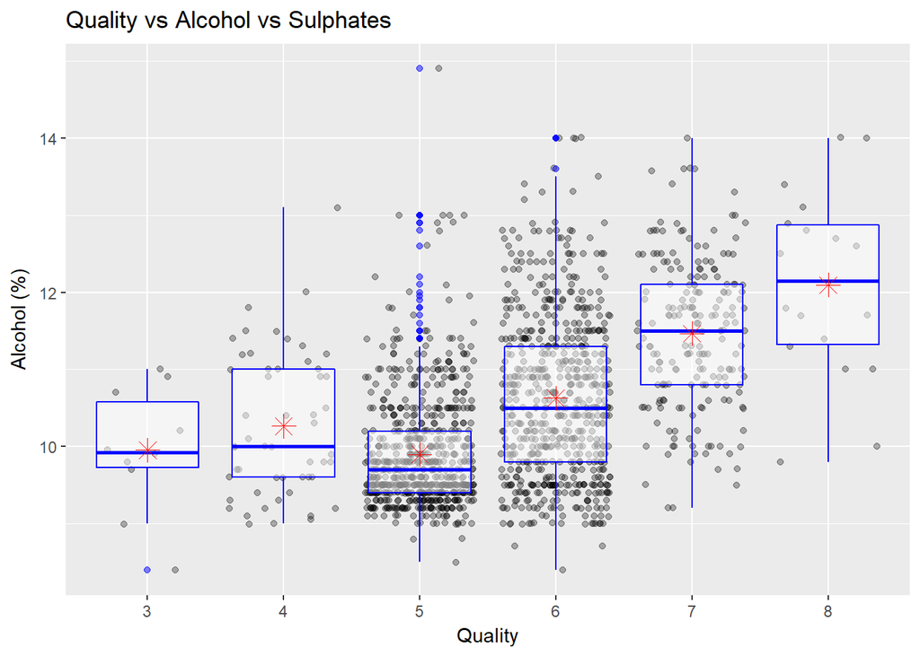

Also we can see removing outliers in Sulphates feature maybe we would have a more clear correlation.

We can do something similar but taking in density feature instead sulphates:

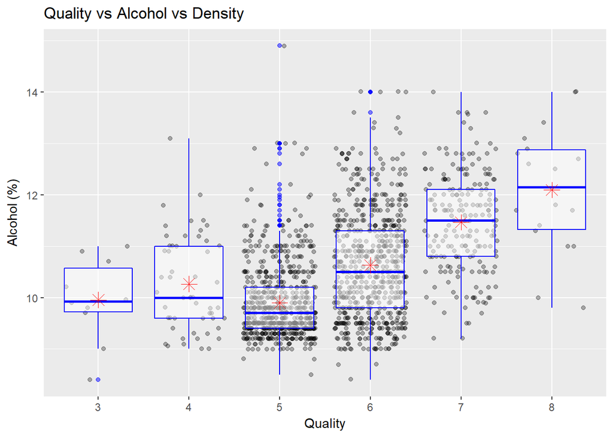

# Final Plots and Summary

### Plot One

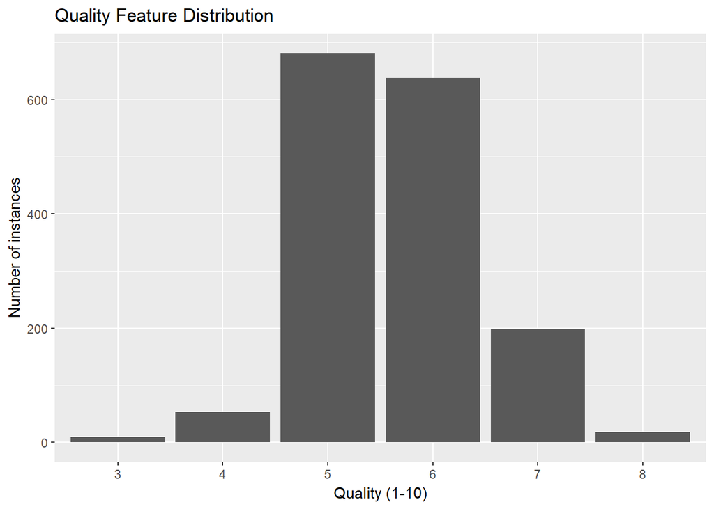

### Description One

First one is the Quality distribution plot. For me is so interesting in terms that have a near normal distribution. You can see there’s a lot mid-market wines and a poor high class wines. Also you can see there’s a little growing on the right. I think it must be related to there’s so few bad wines but also few great ones.

### Plot Two

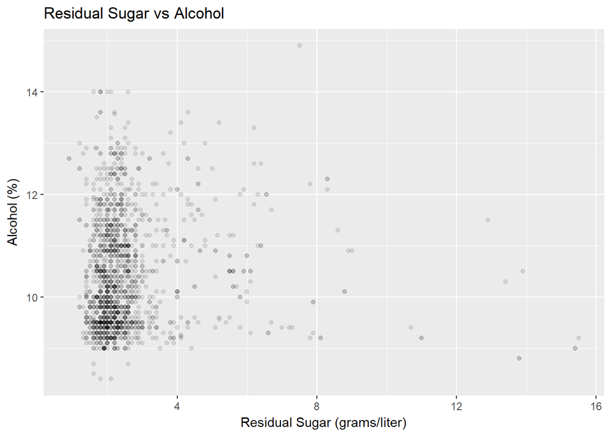

### Description Two

This one is so special for me because it crashes a family theory I’ve heard for years. The more sweet wine the more alcohol you have. It’s clearly not true because no clear relation between the two features.

### Plot Three

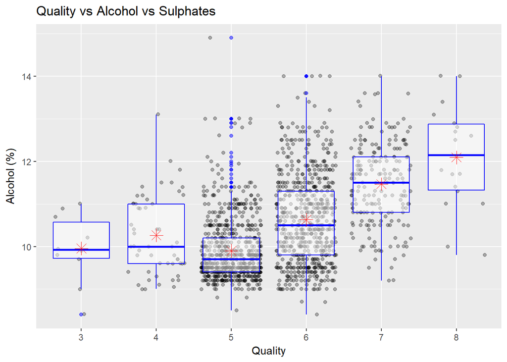

### Description Three

I’ve selected this one because clearly shows us the relation between alcohol and quality but also shows us that there is a lot of range for mid market wines. There’s a strong relation but not enough to ensure high alcohol wines are better.

Finally, if we remove outliers in Sulphates feature may increase correlation with quality.

# Reflection

There’s a lot of wine classes, this is not new. The most of them are mid-market ones. It’s not clear for have an strong model to predict if a wine will be good or not. Here in Spain the wine people thell us that it’s not science, it’s a culture process. I’m not sure about that but with that data can conclude it would not be easy to define the relation.

For me the next steps will be more depth cleaning the data to see if can find strongest correlations with quality.

In the top of my thougs would be great to have a model that can predict quality for the wine in terms of prediction. Most of wine people can predict: acidity, sulphates entered, etc. They will be crazy if can predict income for every year and Marketing actions to be done…